# Understanding Monthly Reports

# Introduction

The monthly quadrant reports are not easy to understand. The monthly reports are in CS-doc-3799. You have to look at the version that you want. For this example, the version is http://cd-docdb.fnal.gov:8080/cgi-bin/ShowDocument?docid=3799&version=422

The list of files is,

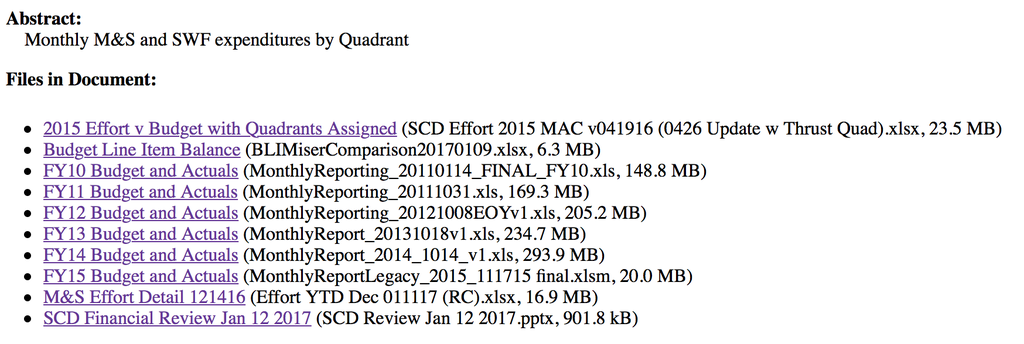

In general, ignore the document titles, like *Budget Line Item Balance*. They usually completely incorrect. Instead, focus on the file name, like `Effort YTD Dec 011117 (RC).xlsx`. This one is for SWF effort up to December. There’s also a presentation that is useful for checking. Here, it is `SCD Review Jan 12 2017.pptx`

## Effort report

The talk budget and actual effort for different months. Let’s see how we get these. Here’s the picture from the talk.

[figure not shown]

In the effort spreadsheet, this is on the sheet `Combined FTE trend` with the appropriate items selected (I can get it to match the talk). Let’s see where these data come from.

What is marked on the slide as *Depts included* are really `Project Number`. The data from this sheet comes from `Combined FTE Pivot`. From there, the data source is `Combined FTEs to Pivot`.

Let’s try to reproduce some of these values.

First, let’s download the file SWF file

```r
library(httr)
library(readxl)
library(dplyr)
library(tidyr)
```

```r
url <- 'http://cd-docdb.fnal.gov:8080/cgi-bin/RetrieveFile?docid=3799&filename=Effort%20YTD%20Dec%20011117%20%28RC%29.xlsx&version=422'
tmp <- tempfile(fileext = '.xlsx')
GET(url, write_disk(tmp), authenticate('cdweb', 'cdpass'))
```

```
Response [http://cd-docdb.fnal.gov:8080/cgi-bin/RetrieveFile?docid=3799&filename=Effort%20YTD%20Dec%20011117%20%28RC%29.xlsx&version=422]
  Date: 2017-01-19 05:17
  Status: 200
  Content-Type: application/vnd.openxmlformats-officedocument.spreadsheetml.sheet
  Size: 17.7 MB
<ON DISK>  /var/folders/5x/gycq58657glgm_2y27bfzy040000gp/T//Rtmp2iKYT9/filea9325fbb7096.xlsx
```

And open the `Data` sheet. There is some confusion when the sheet switches from budget to actual, so we need to specify columns types. Avoid importing a column by setting its type to blank.

```r
coltypes <- c(rep('blank', 8), rep('text', 16), rep('numeric', 2), 'text', 'text', 'numeric',
              rep('text', 7), rep('numeric', 3), rep('text', 3), rep('numeric', 3), 'text',
              rep('numeric', 6), rep('text', 3), rep('blank', 15), rep('text', 10))
d <- read_excel(tmp, 'Data', col_types = coltypes)
```

```r
glimpse(d)
```

```
Observations: 15,195
Variables: 57
$ Activity Level 0         <chr> NA, NA, NA, "DAQ & ENGINEERING", "DAQ & ENGINEERING", "DAQ & ENGINEERING", "C...
$ Activity Level 1         <chr> NA, NA, NA, NA, NA, NA, NA, NA, NA, NA, NA, NA, NA, NA, NA, NA, NA, NA, NA, N...
$ Activity Level 2         <chr> NA, NA, NA, NA, NA, NA, NA, NA, NA, NA, NA, NA, NA, NA, NA, NA, NA, NA, NA, N...
$ Activity Level 3         <chr> NA, NA, NA, NA, NA, NA, NA, NA, NA, NA, NA, NA, NA, NA, NA, NA, NA, NA, NA, N...
$ Activity Level 4         <chr> NA, NA, NA, NA, NA, NA, NA, NA, NA, NA, NA, NA, NA, NA, NA, NA, NA, NA, NA, N...
$ Activity Name            <chr> NA, NA, NA, "DAQ & ENGINEERING", "DAQ & ENGINEERING", "DAQ & ENGINEERING", "C...
$ ActOwningOU              <chr> NA, NA, NA, "FL/SCD/SSA", "FL/SCD/SSA", "FL/SCD/SSA", "FL/CCD/FOP", "FL/SCD/S...
$ ActOwningOUlevel0        <chr> NA, NA, NA, "FL", "FL", "FL", "FL", "FL", "FL", "FL", "FL", "FL", NA, "FL", "...
$ ActOwningOUlevel1        <chr> NA, NA, NA, "SCD", "SCD", "SCD", "CCD", "SCD", "CCD", "CD", "SCD", "SCD", NA,...
$ ActOwningOUlevel2        <chr> NA, NA, NA, "SSA", "SSA", "SSA", "FOP", "SCS", "INF", "OCIO", "SCP", "SCS", N...
$ ActOwningOUlevel3        <chr> NA, NA, NA, NA, NA, NA, NA, "SDP", NA, "SM", "EAG", "SDP", NA, NA, "EAG", "EA...
$ ActOwningOUlevel4        <chr> NA, NA, NA, NA, NA, NA, NA, NA, NA, "COM", NA, NA, NA, NA, NA, NA, NA, NA, NA...
$ ActOwningOUlevel5        <chr> NA, NA, NA, NA, NA, NA, NA, NA, NA, NA, NA, NA, NA, NA, NA, NA, NA, NA, NA, N...
```

[output cut: 44 more lines]

## Recorded Effort

Some notes, `BLI Number` is always blank. Instead, use `bgt_ItemID`. `Project` 9999 is sick, vacation or “opto” time (have to parse `Activity Name` to figure out which).

Let’s pull out effort information infomation about me.

```r
nNonPeriodCols = 4
d %>% filter(`Employee Name` == 'PARA, ADAM', `Record Type` == 'Effort', `Project Number` != 9999) %>%
  select(  activity = `Activity Name`, project = `Project Number`,srv = ServiceType, bnr = `BNR CATEGORY`,
           period = eft_ReportingPeriod, fte = eft_YTDAdjustedEffortyrs ) -> d1
d1
```

| activity | project | srv | bnr | period | fte |
| --- | --- | --- | --- | --- | --- |
| DAQ AND ENGINEERING / Project / DAQ Support for Detector RandD | 51 | OP-FUTURE R&D-DET | KA2501032 | 10/1/2016 | 0.012943787 |
| DAQ AND ENGINEERING / Project / DAQ Support for Detector RandD | 51 | OP-FUTURE R&D-DET | KA2501032 | 10/1/2016 | 0.012943787 |
| DAQ AND ENGINEERING / Project / DAQ Support for Detector RandD | 51 | OP-FUTURE R&D-DET | KA2501032 | 10/1/2016 | 0.012943787 |
| DAQ AND ENGINEERING / Project / DAQ Support for Detector RandD | 51 | OP-FUTURE R&D-DET | KA2501032 | 11/1/2016 | 0.012943787 |
| DAQ AND ENGINEERING / Project / DAQ Support for Detector RandD | 51 | OP-FUTURE R&D-DET | KA2501032 | 11/1/2016 | 0.012943787 |
| DAQ AND ENGINEERING / Project / DAQ Support for Detector RandD | 51 | OP-FUTURE R&D-DET | KA2501032 | 11/1/2016 | 0.012943787 |
| DAQ AND ENGINEERING / Project / DAQ Support for Detector RandD | 51 | OP-FUTURE R&D-DET | KA2501032 | 11/1/2016 | 0.010355030 |
| DAQ AND ENGINEERING / Project / DAQ Support for Detector RandD | 51 | OP-FUTURE R&D-DET | KA2501032 | 12/1/2016 | 0.012943787 |
| DAQ AND ENGINEERING / Project / DAQ Support for Detector RandD | 51 | OP-FUTURE R&D-DET | KA2501032 | 12/1/2016 | 0.010355030 |
| DAQ AND ENGINEERING / Project / DAQ Support for Detector RandD | 51 | OP-FUTURE R&D-DET | KA2501032 | 12/1/2016 | 0.011649408 |

[output cut: 12 more lines]

Note that rows are repeated. There’s an entry per week (the period doesn’t include the week). Let’s group over period.

```r
d1 %>% group_by(activity, project, srv, bnr, period) -> d1g
d1g %>% summarize(fte = sum(fte)) -> d1s
d1s
```

| activity | project | srv | bnr | period | fte |
| --- | --- | --- | --- | --- | --- |
| DAQ AND ENGINEERING / Project / DAQ Support for Detector RandD | 51 | OP-FUTURE R&D-DET | KA2501032 | 10/1/2016 | 0.038831361 |
| DAQ AND ENGINEERING / Project / DAQ Support for Detector RandD | 51 | OP-FUTURE R&D-DET | KA2501032 | 11/1/2016 | 0.049186391 |
| DAQ AND ENGINEERING / Project / DAQ Support for Detector RandD | 51 | OP-FUTURE R&D-DET | KA2501032 | 12/1/2016 | 0.034948225 |
| EXPERIMENT MODELING / Operations / Calorimeter RandD | 51 | OP-R&D-INTENSITY | KA220102 | 10/1/2016 | 0.002588757 |
| INTENSITY FRONTIER / Science / Research | 51 | OP-R&D-INTENSITY | KA220102 | 10/1/2016 | 0.041420118 |
| INTENSITY FRONTIER / Science / Research | 51 | OP-R&D-INTENSITY | KA220102 | 11/1/2016 | 0.049186391 |
| INTENSITY FRONTIER / Science / Research | 51 | OP-R&D-INTENSITY | KA220102 | 12/1/2016 | 0.034948225 |

Let’s see if we can match the `Combinded FTE Trend` sheet. We need to spread the dates. See http://stackoverflow.com/questions/35575910/calculate-subtotals-with-dplyr-and-tidyr for how to add the margins (a little tricky).

```r
notThese = -1:(-1*nNonPeriodCols)
d1s %>% spread(period, fte, fill = 0.0) %>%
  ungroup() %>%
  mutate( Total = rowSums(.[notThese])) %>%
  rbind(., data.frame(activity='Total', project="", srv="", bnr="",
                      t(colSums(.[notThese])), check.names = F, fix.empty.names=F))
```

|  | activity | project | srv | bnr | 10/1/2016 | 11/1/2016 | 12/1/2016 | Total |
| --- | --- | --- | --- | --- | --- | --- | --- | --- |
| 1 | DAQ AND ENGINEERING / Project / DAQ Support for Detector RandD | 51 | OP-FUTURE R&D-DET | KA2501032 | 0.038831361 | 0.04918639 | 0.03494822 | 0.122965976 |
| 2 | EXPERIMENT MODELING / Operations / Calorimeter RandD | 51 | OP-R&D-INTENSITY | KA220102 | 0.002588757 | 0.00000000 | 0.00000000 | 0.002588757 |
| 3 | INTENSITY FRONTIER / Science / Research | 51 | OP-R&D-INTENSITY | KA220102 | 0.041420118 | 0.04918639 | 0.03494822 | 0.125554734 |
| 4 | Total |  |  |  | 0.082840237 | 0.09837278 | 0.06989645 | 0.251109467 |

Would be nice to somehow automate the adding of `activity`, `project`, and `srv` for the margins.

## Budgeted Effort

Let’s try to get the budget layout for a person. Then we’ll try for an activity.

```r
d %>% filter(`Employee Name` == 'PARA, ADAM', `Record Type` == 'Budget') %>%
  select(  activity = `Activity Name`, project = `Project Number`,srv = ServiceType, bnr = `BNR CATEGORY`,
           fte = bgt_FTE, cost = bgt_Budget_entered ) -> b
b
```

| activity | project | srv | bnr | fte | cost |
| --- | --- | --- | --- | --- | --- |
| DAQ AND ENGINEERING / Project / DAQ Support for Detector RandD | 51 | OP-FUTURE R&D-DET | KA2501032 | 0.5 | 78000 |
| INTENSITY FRONTIER / Science / Research | 51 | OP-R&D-INTENSITY | KA220102 | 0.5 | 78000 |
| EXPERIMENT MODELING / Operations / Calorimeter RandD | 51 | OP-R&D-INTENSITY | KA220102 | 0.0 | 0 |

## Budget totals for DOE Competence

For the DOE competence project I need sum FTEs for various competencies

Let’s get a list of all the unique activities that are budgeted.

```r
d %>% filter(`Record Type` == 'Budget') %>%
      select(activity = `Activity Name`, act0 = `Activity Level 0`, act1 = `Activity Level 1`, act2 = `Activity Level 2`,
             div = ActOwningOUlevel1, quadrant = ActOwningOUlevel2, dept = ActOwningOUlevel3,
             project = `Project Number`, srv = ServiceType, bnr = `BNR CATEGORY`
             ) %>%
      distinct(activity, .keep_all=T) %>%
      arrange(div, quadrant, dept, activity) -> acts
```

Let’s pick one for testing…

```r
acts %>% filter(act0 == 'SCIENTIFIC SOFTWARE', act2 == 'Frameworks', project != 583)
```

| activity | act0 | act1 | act2 | div | quadrant | dept | project | srv | bnr |
| --- | --- | --- | --- | --- | --- | --- | --- | --- | --- |
| SCIENTIFIC SOFTWARE / Operations / Frameworks / Training | SCIENTIFIC SOFTWARE | Operations | Frameworks | SCD | SSA | SSI | 51 | OP-EXST PRGM OP-DET | KA2202022 |
| SCIENTIFIC SOFTWARE / Project / Frameworks / art | SCIENTIFIC SOFTWARE | Project | Frameworks | SCD | SSA | SSI | 51 | OP-EXST PRGM OP-DET | KA2202022 |
| SCIENTIFIC SOFTWARE / Project / Frameworks / cmssw | SCIENTIFIC SOFTWARE | Project | Frameworks | SCD | SSA | SSI | 55 | OP-LHC-CMS S&C | KA2102022 |

Ok - What we really want is the FTE and money level for each activity (add up over people). We can remove the distinct verb and then do group by

```r
d %>% filter(`Record Type` == 'Budget') %>%
      select(activity = `Activity Name`, act0 = `Activity Level 0`, act1 = `Activity Level 1`,
             act2 = `Activity Level 2`, act3 = `Activity Level 3`,
             div = ActOwningOUlevel1, quadrant = ActOwningOUlevel2, dept = ActOwningOUlevel3,
             project = `Project Number`, srv = ServiceType, bnr = `BNR CATEGORY`, who = `Employee Name`,
             fte = bgt_FTE, cost = bgt_Budget_entered
             ) %>%
      group_by(activity) -> actg
```

```r
actg %>% summarise( nPeople = n(), fte = sum(fte)) -> actg_byact
head(actg_byact)
```

| activity | nPeople | fte |
| --- | --- | --- |
| ACCELERATOR MODELING / Management / Line Management | 2 | 0.1000000 |
| ACCELERATOR MODELING / Project / CHEF | 1 | 0.3333333 |
| ACCELERATOR MODELING / Project / COMPASS / CS | 5 | 0.8000000 |
| ACCELERATOR MODELING / Project / McMillan Nonlinear Focussing | 1 | 0.1800000 |
| ACCELERATOR MODELING / Project / PIP | 2 | 1.0700000 |
| ACCELERATOR MODELING / Project / Simulation Development | 6 | 1.5700000 |

The above leaves out the columns that I want to see

```r
actg %>% mutate( nPeople = n(), sumFTE = sum(fte),
                 sumCost=sum(cost)) %>% slice(1) %>% select(-who, -fte, -cost) ->  byact
head(byact)
```

| activity | act0 | act1 | act2 | act3 | div | quadrant | dept | project | srv | bnr | nPeople | sumFTE | sumCost |
| --- | --- | --- | --- | --- | --- | --- | --- | --- | --- | --- | --- | --- | --- |
| ACCELERATOR MODELING / Management / Line Management | ACCELERATOR MODELING | Management | Line Management | NA | SCD | SSA | SCS | 51 | OP-FUTURE R&D-ACCEL | KA2501012 | 2 | 0.1000000 | 15600 |
| ACCELERATOR MODELING / Project / CHEF | ACCELERATOR MODELING | Project | CHEF | NA | SCD | SSA | SCS | 51 | OP-FUTURE R&D-ACCEL | KA2501012 | 1 | 0.3333333 | 52000 |
| ACCELERATOR MODELING / Project / COMPASS / CS | ACCELERATOR MODELING | Project | COMPASS | CS | SCD | SSA | SCS | 531 | OP-COMPUTING R&D-COMP PART | KJ0403 | 5 | 0.8000000 | 124800 |
| ACCELERATOR MODELING / Project / McMillan Nonlinear Focussing | ACCELERATOR MODELING | Project | McMillan Nonlinear Focussing | NA | SCD | SSA | SCS | 51 | OP-FUTURE R&D-ACCEL | KA2501012 | 1 | 0.1800000 | 28080 |
| ACCELERATOR MODELING / Project / PIP | ACCELERATOR MODELING | Project | PIP | NA | SCD | SSA | SCS | 51 | OP-EXST PRGM OP-ACCEL | KA2202021 | 2 | 1.0700000 | 166920 |
| ACCELERATOR MODELING / Project / Simulation Development | ACCELERATOR MODELING | Project | Simulation Development | NA | SCD | SSA | SCS | 51 | OP-FUTURE R&D-ACCEL | KA2501012 | 6 | 1.5700000 | 244920 |

The above keeps the columns, but also keeps the employee name which doesn’t work. So it is removed.

That looks good!

### Data Analytics Software Infrastructure Support

Should include all art, CMSSW, LArSoft, and Geant support (including Phillipe for Root). What about Cosmosis?

art and CMSSW are (not CompHEP money on 583),

```r
byact %>% filter(act0 == 'SCIENTIFIC SOFTWARE', act2 == 'Frameworks', project != 583) -> infra1
infra1
```

| activity | act0 | act1 | act2 | act3 | div | quadrant | dept | project | srv | bnr | nPeople | sumFTE | sumCost |
| --- | --- | --- | --- | --- | --- | --- | --- | --- | --- | --- | --- | --- | --- |
| SCIENTIFIC SOFTWARE / Operations / Frameworks / Training | SCIENTIFIC SOFTWARE | Operations | Frameworks | Training | SCD | SSA | SSI | 51 | OP-EXST PRGM OP-DET | KA2202022 | 1 | 0.10 | 15600 |
| SCIENTIFIC SOFTWARE / Project / Frameworks / art | SCIENTIFIC SOFTWARE | Project | Frameworks | art | SCD | SSA | SSI | 51 | OP-EXST PRGM OP-DET | KA2202022 | 2 | 0.80 | 124800 |
| SCIENTIFIC SOFTWARE / Project / Frameworks / cmssw | SCIENTIFIC SOFTWARE | Project | Frameworks | cmssw | SCD | SSA | SSI | 55 | OP-LHC-CMS S&C | KA2102022 | 5 | 2.75 | 429000 |

Panagiotis should have included (I DO NOT INCLUD THIS),

```r
byact %>% filter(act0 == 'SCIENTIFIC SOFTWARE', act2 == 'Frameworks', project == 583)
```

| activity | act0 | act1 | act2 | act3 | div | quadrant | dept | project | srv | bnr | nPeople | sumFTE | sumCost |
| --- | --- | --- | --- | --- | --- | --- | --- | --- | --- | --- | --- | --- | --- |
| SCIENTIFIC SOFTWARE / Project / Frameworks / HPC art | SCIENTIFIC SOFTWARE | Project | Frameworks | HPC art | SCD | SSA | SSI | 583 | OP-THEORY-COMPUTATION-ADD | KA2401022 | 1 | 0.50 | 78000 |
| SCIENTIFIC SOFTWARE / Project / Frameworks / RandD | SCIENTIFIC SOFTWARE | Project | Frameworks | RandD | SCD | SSA | SCS | 583 | OP-THEORY-COMPUTATION-ADD | KA2401022 | 6 | 2.35 | 366600 |

Why is the department SCS for art R&D?

```r
actg %>% filter(act0 == 'SCIENTIFIC SOFTWARE', act2 == 'Frameworks', project == 583) %>% select(activity, dept, who, fte)
```

| activity | dept | who | fte |
| --- | --- | --- | --- |
| SCIENTIFIC SOFTWARE / Project / Frameworks / RandD | SCS | KOWALKOWSKI, JAMES | 0.65 |
| SCIENTIFIC SOFTWARE / Project / Frameworks / RandD | SCS | AMUNDSON, JAMES | 0.30 |
| SCIENTIFIC SOFTWARE / Project / Frameworks / RandD | SCS | GREEN, CHRISTOPHER | 0.10 |
| SCIENTIFIC SOFTWARE / Project / Frameworks / RandD | SCS | RUSSO, PAUL | 0.20 |
| SCIENTIFIC SOFTWARE / Project / Frameworks / RandD | SCS | KNOEPFEL, KYLE | 0.90 |
| SCIENTIFIC SOFTWARE / Project / Frameworks / RandD | SCS | PATERNO, MARC | 0.20 |
| SCIENTIFIC SOFTWARE / Project / Frameworks / HPC art | SSI | STAPLETON, JAMES | 0.50 |

Hmm - the department is wrong for lots of people in SSI!!! Harumph.

LArSoft is

```r
byact %>% filter(act0 == 'SCIENTIFIC SOFTWARE', act2 == 'larsoft', is.na(act3) | act3 != 'Project Management') ->
      infra2
infra2
```

| activity | act0 | act1 | act2 | act3 | div | quadrant | dept | project | srv | bnr | nPeople | sumFTE | sumCost |
| --- | --- | --- | --- | --- | --- | --- | --- | --- | --- | --- | --- | --- | --- |
| SCIENTIFIC SOFTWARE / Operations / larsoft | SCIENTIFIC SOFTWARE | Operations | larsoft | NA | SCD | SCO | NA | 51 | OP-EXST PRGM OP-DET | KA2202022 | 1 | 0.30 | 46800 |
| SCIENTIFIC SOFTWARE / Project / larsoft | SCIENTIFIC SOFTWARE | Project | larsoft | NA | SCD | SCS | SDCS | 51 | OP-EXST PRGM OP-DET | KA2202022 | 3 | 1.55 | 241800 |

The management part should not be included.

Geant support is (I’m assuming I don’t include Genie nor Pythia)

```r
byact %>% filter(act0 == "EXPERIMENT MODELING", act1 == 'Operations', act2 == 'Geant4' | act2 == 'CMS') -> infra3
infra3
```

| activity | act0 | act1 | act2 | act3 | div | quadrant | dept | project | srv | bnr | nPeople | sumFTE | sumCost |
| --- | --- | --- | --- | --- | --- | --- | --- | --- | --- | --- | --- | --- | --- |
| EXPERIMENT MODELING / Operations / CMS | EXPERIMENT MODELING | Operations | CMS | NA | SCD | SSA | SCS | 51 | OP-R&D-ENERGY | KA210102 | 1 | 0.3 | 46800 |
| EXPERIMENT MODELING / Operations / Geant4 / Computing Performance | EXPERIMENT MODELING | Operations | Geant4 | Computing Performance | SCD | SSA | SCS | 583 | OP-THEORY-COMPUTATION-ADD | KA2401022 | 5 | 0.8 | 124800 |
| EXPERIMENT MODELING / Operations / Geant4 / General Support | EXPERIMENT MODELING | Operations | Geant4 | General Support | SCD | SSA | SCS | 51 | OP-EXST PRGM OP-DET | KA2202022 | 3 | 0.3 | 46800 |
| EXPERIMENT MODELING / Operations / Geant4 / Physics and Validation | EXPERIMENT MODELING | Operations | Geant4 | Physics and Validation | SCD | SSA | SCS | 583 | OP-THEORY-COMPUTATION-ADD | KA2401022 | 5 | 1.4 | 218400 |

Where is Phillipe’s Root work?

```r
actg %>% filter(who == 'CANAL, PHILIPPE')
```

| activity | act0 | act1 | act2 | act3 | div | quadrant | dept | project | srv | bnr | who | fte | cost |
| --- | --- | --- | --- | --- | --- | --- | --- | --- | --- | --- | --- | --- | --- |
| SCIENTIFIC SOFTWARE / Operations / ROOT | SCIENTIFIC SOFTWARE | Operations | ROOT | NA | SCD | SCS | SDPS | 55 | OP-LHC-CMS S&C | KA2102022 | CANAL, PHILIPPE | 0.55 | 85800 |
| EXPERIMENT MODELING / Project / Geant4 / RandD | EXPERIMENT MODELING | Project | Geant4 | RandD | SCD | SSA | SCS | 573 | OP-THEORY-SCIDAC-ADD | KA2401021 | CANAL, PHILIPPE | 0.40 | 62400 |
| EXPERIMENT MODELING / Operations / Geant4 / Computing Performance | EXPERIMENT MODELING | Operations | Geant4 | Computing Performance | SCD | SSA | SCS | 583 | OP-THEORY-COMPUTATION-ADD | KA2401022 | CANAL, PHILIPPE | 0.05 | 7800 |

So,

```r
byact %>% filter(act0 == 'SCIENTIFIC SOFTWARE', act1 == 'Operations', act2 == 'ROOT') -> infra4
infra4
```

| activity | act0 | act1 | act2 | act3 | div | quadrant | dept | project | srv | bnr | nPeople | sumFTE | sumCost |
| --- | --- | --- | --- | --- | --- | --- | --- | --- | --- | --- | --- | --- | --- |
| SCIENTIFIC SOFTWARE / Operations / ROOT | SCIENTIFIC SOFTWARE | Operations | ROOT | NA | SCD | SCS | SDPS | 55 | OP-LHC-CMS S&C | KA2102022 | 1 | 0.55 | 85800 |

Including Cosmosis give,

```r
byact %>% filter(act0 == 'SCIENTIFIC SOFTWARE', act3 == 'CosmoSIS') -> infra5
infra5
```

| activity | act0 | act1 | act2 | act3 | div | quadrant | dept | project | srv | bnr | nPeople | sumFTE | sumCost |
| --- | --- | --- | --- | --- | --- | --- | --- | --- | --- | --- | --- | --- | --- |
| SCIENTIFIC SOFTWARE / Project / Workflows / CosmoSIS | SCIENTIFIC SOFTWARE | Project | Workflows | CosmoSIS | SCD | SSA | SSI | 40B | OP-ASTRO-OFFSITE | KA230201 | 3 | 0.8 | 124800 |

Add them up!

```r
infra <- rbind(infra1, infra2, infra3, infra4, infra5)
infra %>% select(activity, project, bnr, srv, nPeople, sumFTE, sumCost)
```

| activity | project | bnr | srv | nPeople | sumFTE | sumCost |
| --- | --- | --- | --- | --- | --- | --- |
| SCIENTIFIC SOFTWARE / Operations / Frameworks / Training | 51 | KA2202022 | OP-EXST PRGM OP-DET | 1 | 0.10 | 15600 |
| SCIENTIFIC SOFTWARE / Project / Frameworks / art | 51 | KA2202022 | OP-EXST PRGM OP-DET | 2 | 0.80 | 124800 |
| SCIENTIFIC SOFTWARE / Project / Frameworks / cmssw | 55 | KA2102022 | OP-LHC-CMS S&C | 5 | 2.75 | 429000 |
| SCIENTIFIC SOFTWARE / Operations / larsoft | 51 | KA2202022 | OP-EXST PRGM OP-DET | 1 | 0.30 | 46800 |
| SCIENTIFIC SOFTWARE / Project / larsoft | 51 | KA2202022 | OP-EXST PRGM OP-DET | 3 | 1.55 | 241800 |
| EXPERIMENT MODELING / Operations / CMS | 51 | KA210102 | OP-R&D-ENERGY | 1 | 0.30 | 46800 |
| EXPERIMENT MODELING / Operations / Geant4 / Computing Performance | 583 | KA2401022 | OP-THEORY-COMPUTATION-ADD | 5 | 0.80 | 124800 |
| EXPERIMENT MODELING / Operations / Geant4 / General Support | 51 | KA2202022 | OP-EXST PRGM OP-DET | 3 | 0.30 | 46800 |
| EXPERIMENT MODELING / Operations / Geant4 / Physics and Validation | 583 | KA2401022 | OP-THEORY-COMPUTATION-ADD | 5 | 1.40 | 218400 |
| SCIENTIFIC SOFTWARE / Operations / ROOT | 55 | KA2102022 | OP-LHC-CMS S&C | 1 | 0.55 | 85800 |

[output cut: 1 more lines]

And the answers!

```r
infra %>% ungroup %>% summarise(totalFTE = sum(sumFTE), totalCost = sum(sumCost))
```

| totalFTE | totalCost |
| --- | --- |
| 9.65 | 1505400 |

### Physics modeling

Accelerator modeling. Everything but management

```r
byact %>% filter(act0 == 'ACCELERATOR MODELING', act1 != 'Management', act1 != 'Science') -> modl1
modl1
```

| activity | act0 | act1 | act2 | act3 | div | quadrant | dept | project | srv | bnr | nPeople | sumFTE | sumCost |
| --- | --- | --- | --- | --- | --- | --- | --- | --- | --- | --- | --- | --- | --- |
| ACCELERATOR MODELING / Project / CHEF | ACCELERATOR MODELING | Project | CHEF | NA | SCD | SSA | SCS | 51 | OP-FUTURE R&D-ACCEL | KA2501012 | 1 | 0.3333333 | 52000 |
| ACCELERATOR MODELING / Project / COMPASS / CS | ACCELERATOR MODELING | Project | COMPASS | CS | SCD | SSA | SCS | 531 | OP-COMPUTING R&D-COMP PART | KJ0403 | 5 | 0.8000000 | 124800 |
| ACCELERATOR MODELING / Project / McMillan Nonlinear Focussing | ACCELERATOR MODELING | Project | McMillan Nonlinear Focussing | NA | SCD | SSA | SCS | 51 | OP-FUTURE R&D-ACCEL | KA2501012 | 1 | 0.1800000 | 28080 |
| ACCELERATOR MODELING / Project / PIP | ACCELERATOR MODELING | Project | PIP | NA | SCD | SSA | SCS | 51 | OP-EXST PRGM OP-ACCEL | KA2202021 | 2 | 1.0700000 | 166920 |
| ACCELERATOR MODELING / Project / Simulation Development | ACCELERATOR MODELING | Project | Simulation Development | NA | SCD | SSA | SCS | 51 | OP-FUTURE R&D-ACCEL | KA2501012 | 6 | 1.5700000 | 244920 |

Pythia - What does Mrenna report to?

```r
actg %>% filter( who == 'MRENNA, STEPHEN' | who == 'PERDUE, GABRIEL')
```

| activity | act0 | act1 | act2 | act3 | div | quadrant | dept | project | srv | bnr | who | fte | cost |
| --- | --- | --- | --- | --- | --- | --- | --- | --- | --- | --- | --- | --- | --- |
| INTENSITY FRONTIER / Science / Research | INTENSITY FRONTIER | Science | Research | NA | SCD | SCP | NA | 51 | OP-R&D-INTENSITY | KA220102 | PERDUE, GABRIEL | 0.50 | 78000 |
| SCD DIVISION WORK / Operations / Liaison | SCD DIVISION WORK | Operations | Liaison | NA | SCD | NA | NA | 51 | OP-EXST PRGM OP-DET | KA2202022 | PERDUE, GABRIEL | 0.10 | 15600 |
| EXPERIMENT MODELING / Operations / Pythia | EXPERIMENT MODELING | Operations | Pythia | NA | SCD | SSA | SCS | 51 | OP-R&D-ENERGY | KA210102 | MRENNA, STEPHEN | 0.20 | 31200 |
| EXPERIMENT MODELING / Operations / Genie | EXPERIMENT MODELING | Operations | Genie | NA | SCD | SSA | SCS | 51 | OP-EXST PRGM OP-DET | KA2202022 | PERDUE, GABRIEL | 0.25 | 39000 |
| EXPERIMENT MODELING / Operations / Genie | EXPERIMENT MODELING | Operations | Genie | NA | SCD | SSA | SCS | 51 | OP-EXST PRGM OP-DET | KA2202022 | MRENNA, STEPHEN | 0.00 | 0 |
| EXPERIMENT MODELING / Operations / CMS | EXPERIMENT MODELING | Operations | CMS | NA | SCD | SSA | SCS | 51 | OP-R&D-ENERGY | KA210102 | MRENNA, STEPHEN | 0.30 | 46800 |
| ENERGY FRONTIER / Science / SCD-CMS Physics Research | ENERGY FRONTIER | Science | SCD-CMS Physics Research | NA | SCD | SCP | CMS | 51 | OP-R&D-ENERGY | KA210102 | MRENNA, STEPHEN | 0.50 | 78000 |
| EXPERIMENT MODELING / Science / Intensity Frontier Experiments | EXPERIMENT MODELING | Science | Intensity Frontier Experiments | NA | SCD | SSA | SCS | 51 | OP-R&D-INTENSITY | KA220102 | PERDUE, GABRIEL | 0.15 | 23400 |

```r
byact %>% filter(act0 == 'EXPERIMENT MODELING', act1 == 'Operations', act2 %in% c('Pythia', 'Genie')) -> modl2
modl2
```

| activity | act0 | act1 | act2 | act3 | div | quadrant | dept | project | srv | bnr | nPeople | sumFTE | sumCost |
| --- | --- | --- | --- | --- | --- | --- | --- | --- | --- | --- | --- | --- | --- |
| EXPERIMENT MODELING / Operations / Genie | EXPERIMENT MODELING | Operations | Genie | NA | SCD | SSA | SCS | 51 | OP-EXST PRGM OP-DET | KA2202022 | 4 | 1.15 | 179400 |
| EXPERIMENT MODELING / Operations / Pythia | EXPERIMENT MODELING | Operations | Pythia | NA | SCD | SSA | SCS | 51 | OP-R&D-ENERGY | KA210102 | 1 | 0.20 | 31200 |

Why is Genie four people?

```r
actg %>% filter( activity == 'EXPERIMENT MODELING / Operations / Genie')
```

| activity | act0 | act1 | act2 | act3 | div | quadrant | dept | project | srv | bnr | who | fte | cost |
| --- | --- | --- | --- | --- | --- | --- | --- | --- | --- | --- | --- | --- | --- |
| EXPERIMENT MODELING / Operations / Genie | EXPERIMENT MODELING | Operations | Genie | NA | SCD | SSA | SCS | 51 | OP-EXST PRGM OP-DET | KA2202022 | YARBA, JULIA | 0.40 | 62400 |
| EXPERIMENT MODELING / Operations / Genie | EXPERIMENT MODELING | Operations | Genie | NA | SCD | SSA | SCS | 51 | OP-EXST PRGM OP-DET | KA2202022 | PERDUE, GABRIEL | 0.25 | 39000 |
| EXPERIMENT MODELING / Operations / Genie | EXPERIMENT MODELING | Operations | Genie | NA | SCD | SSA | SCS | 51 | OP-EXST PRGM OP-DET | KA2202022 | MRENNA, STEPHEN | 0.00 | 0 |
| EXPERIMENT MODELING / Operations / Genie | EXPERIMENT MODELING | Operations | Genie | NA | SCD | SSA | SCS | 51 | OP-EXST PRGM OP-DET | KA2202022 | HATCHER, ROBERT | 0.50 | 78000 |

All I need left is Geant R&D

```r
byact %>% filter(activity == 'EXPERIMENT MODELING / Project / Geant4 / RandD') -> modl3
modl3
```

| activity | act0 | act1 | act2 | act3 | div | quadrant | dept | project | srv | bnr | nPeople | sumFTE | sumCost |
| --- | --- | --- | --- | --- | --- | --- | --- | --- | --- | --- | --- | --- | --- |
| EXPERIMENT MODELING / Project / Geant4 / RandD | EXPERIMENT MODELING | Project | Geant4 | RandD | SCD | SSA | SCS | 573 | OP-THEORY-SCIDAC-ADD | KA2401021 | 4 | 1.9 | 296400 |

Add them up!

```r
modl <- rbind(modl1, modl2, modl3)
modl %>% select(activity, project, bnr, srv, nPeople, sumFTE, sumCost)
```

| activity | project | bnr | srv | nPeople | sumFTE | sumCost |
| --- | --- | --- | --- | --- | --- | --- |
| ACCELERATOR MODELING / Project / CHEF | 51 | KA2501012 | OP-FUTURE R&D-ACCEL | 1 | 0.3333333 | 52000 |
| ACCELERATOR MODELING / Project / COMPASS / CS | 531 | KJ0403 | OP-COMPUTING R&D-COMP PART | 5 | 0.8000000 | 124800 |
| ACCELERATOR MODELING / Project / McMillan Nonlinear Focussing | 51 | KA2501012 | OP-FUTURE R&D-ACCEL | 1 | 0.1800000 | 28080 |
| ACCELERATOR MODELING / Project / PIP | 51 | KA2202021 | OP-EXST PRGM OP-ACCEL | 2 | 1.0700000 | 166920 |
| ACCELERATOR MODELING / Project / Simulation Development | 51 | KA2501012 | OP-FUTURE R&D-ACCEL | 6 | 1.5700000 | 244920 |
| EXPERIMENT MODELING / Operations / Genie | 51 | KA2202022 | OP-EXST PRGM OP-DET | 4 | 1.1500000 | 179400 |
| EXPERIMENT MODELING / Operations / Pythia | 51 | KA210102 | OP-R&D-ENERGY | 1 | 0.2000000 | 31200 |
| EXPERIMENT MODELING / Project / Geant4 / RandD | 573 | KA2401021 | OP-THEORY-SCIDAC-ADD | 4 | 1.9000000 | 296400 |

And the answers!

```r
modl %>% ungroup %>% summarise(totalFTE = sum(sumFTE), totalCost = sum(sumCost))
```

| totalFTE | totalCost |
| --- | --- |
| 7.203333 | 1123720 |